# SEVIS analysis

Ian Hodgson

2025-08-19

## Data description and issues

This analysis uses data from the Student and Exchange Visitor Information System (SEVIS), the system that the Department of Homeland Security (DHS) uses to maintain information on F and M students in the United States. This data includes the students’ country of citizenship, what U.S. school they attend and what they study.

Until 2023, the data was available quarterly or three-times annually. After 2023 the data is available monthly. Unfortunately, that means that year-over-year comparisions are difficult, if not impossible, prior to 2023.

Below is a table showing the months available for each year.

|  | year | month |
| --- | --- | --- |
| 1 | 2014 | 4 |
| 2 | 2014 | 7 |
| 3 | 2014 | 10 |
| 4 | 2015 | 2 |
| 5 | 2015 | 9 |
| 6 | 2015 | 12 |
| 7 | 2016 | 3 |
| 8 | 2016 | 7 |
| 9 | 2016 | 11 |
| 10 | 2017 | 3 |

[output cut: 47 more lines]

Most counties exhibit a saw-tooth pattern, where visas spike in September and then fall through the year. For example, see Canada’s enrollment trend.

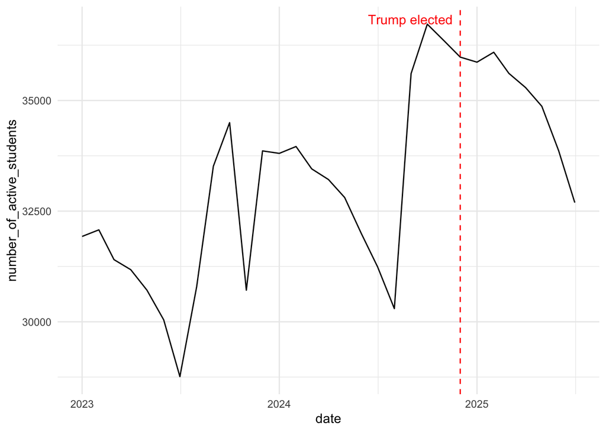

This saw-tooth pattern tells us two things:

1. SEVIS data doesn’t cover the same months every year prior to 2023. For example, in 2015 we have Feb, Sept, Dec and in 2016 we have March, July, Nov. That means we can’t compare year-over-year change for most years or use an annual average. Additionally, we can’t compare a month in one year to an adjacent month in the prior year. For example, we can’t compare Dec. 2015 to Nov. 2016.
2. We should be careful about comparing year-over-year cycles. For example, comparing H12025 with H12024 may tell us more about the 2024-25 school year vs the 2023-24 school year, rather than what enrollment will look like in the 2025-26 school year.

## Where are students coming from?

### Overall trends

Let’s look at the total number of foreign students since 2015. We’ll compare December and March numbers, since the two months have good coverage across years. These numbers include both undergraduates and graduate students.

The results aren’t surprising – we see a large drop in late 2020, early 2021 during the Covid-19 pandemic, which recovers by 2024 and total foreign students pick up in early 2025.

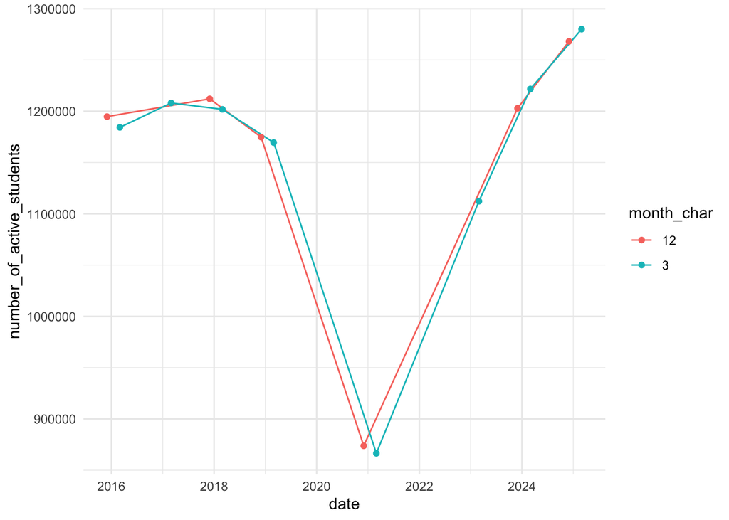

### Country of origin

#### China remains stagnant

Comparing the student numbers for 2022-2024, we can see that China has remained stagnant after a large drop during the Covid-19 pandemic.

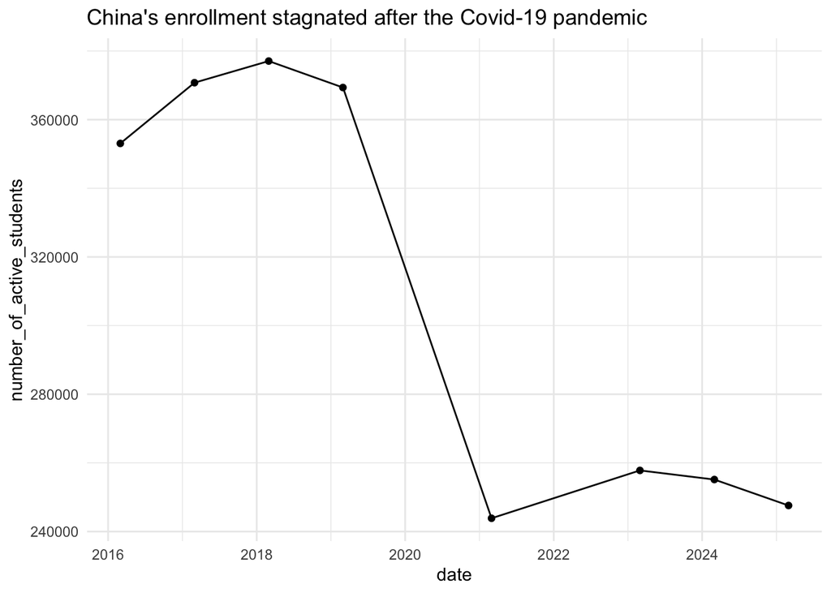

#### Other countries are making up the difference

Instead, the US has look to other countries, namely India, to fill that gap. Brazil, Nepal, Nigeria and Bangladesh also contribute to making up some of that loss. In fact, India surpassed China as the largest exporter of students in 2023.

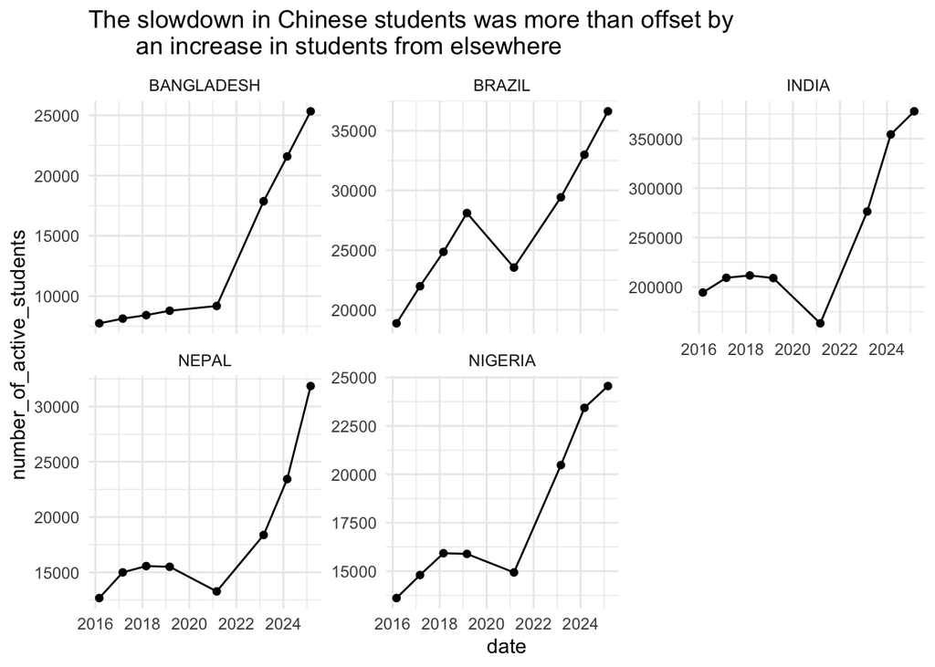

### Table of trends since 2022

Look at September values from 2022-2024

|  | country_of_citizenship | yr_2022 | yr_2023 | yr_2024 | chng_22_23 | chng_23_24 |
| --- | --- | --- | --- | --- | --- | --- |
| 1 | INDIA | 240630 | 338353 | 386960 | 40.6 | 14.4 |
| 2 | CHINA | 251680 | 265387 | 260555 | 5.4 | -1.8 |
| 3 | SOUTH KOREA | 45620 | 48292 | 47222 | 5.9 | -2.2 |
| 4 | CANADA | 29376 | 33516 | 35609 | 14.1 | 6.2 |
| 5 | BRAZIL | 26469 | 31735 | 35047 | 19.9 | 10.4 |
| 6 | VIETNAM | 22861 | 25593 | 29466 | 12 | 15.1 |
| 7 | NEPAL | 17049 | 20397 | 28443 | 19.6 | 39.4 |
| 8 | NIGERIA | 18766 | 23034 | 24699 | 22.7 | 7.2 |
| 9 | BANGLADESH | 14883 | 21146 | 24257 | 42.1 | 14.7 |
| 10 | TAIWAN | 20795 | 22961 | 23406 | 10.4 | 1.9 |

[output cut: 218 more lines]

## Where are students going?

#### Which states are growing the fastest since the pandemic?

On net, California’s foreign student population fell by the most – dropping by 15 percent since 2019.

|  | state | yr_2019 | yr_2021 | yr_2023 | yr_2024 | yr_2025 | chng_19_25 | pct_19_25 |
| --- | --- | --- | --- | --- | --- | --- | --- | --- |
| 1 | TX | 81423 | 62168 | 81581 | 91429 | 98124 | 16701 | 20.5 |
| 2 | MO | 21354 | 14806 | 25301 | 33471 | 35782 | 14428 | 67.6 |
| 3 | NY | 136916 | 100832 | 136585 | 146476 | 150623 | 13707 | 10 |
| 4 | IL | 54382 | 39893 | 55400 | 63185 | 67320 | 12938 | 23.8 |
| 5 | MA | 75681 | 59934 | 79299 | 85319 | 86855 | 11174 | 14.8 |
| 6 | AZ | 20549 | 15956 | 22824 | 26641 | 30161 | 9612 | 46.8 |
| 7 | MI | 32421 | 23322 | 32952 | 37968 | 39591 | 7170 | 22.1 |
| 8 | CT | 16606 | 12327 | 18454 | 22368 | 23366 | 6760 | 40.7 |
| 9 | FL | 59392 | 47343 | 58760 | 63233 | 66088 | 6696 | 11.3 |
| 10 | GA | 25036 | 20876 | 26788 | 29465 | 31527 | 6491 | 25.9 |

[output cut: 45 more lines]

#### What states are losing Chinese students fastest since the pandemic

California saw the largest losses, with the share of Chinese students dropping by nearly a third from 2019 to 2025. Pennsyvania lost more than a third and Ohio lost more than half of its pre-pandemic population of Chinese students.

|  | state | yr_2019 | yr_2021 | yr_2023 | yr_2024 | yr_2025 | chng_19_25 | pct_19_25 |
| --- | --- | --- | --- | --- | --- | --- | --- | --- |
| 1 | MD | 7134 | 4673 | 6847 | 7081 | 7582 | 448 | 6.3 |
| 2 | VI | 0 | 0 | 0 | 0 | 1 | 1 |  |
| 3 | GU | 10 | 7 | 7 | 8 | 10 | 0 | 0 |
| 4 | PR | 15 | 12 | 10 | 73 | 11 | -4 | -26.7 |
| 5 | AK | 30 | 27 | 16 | 12 | 14 | -16 | -53.3 |
| 6 | MP | 158 | 121 | 140 | 119 | 98 | -60 | -38 |
| 7 | SD | 193 | 114 | 91 | 105 | 122 | -71 | -36.8 |
| 8 | MT | 116 | 62 | 41 | 43 | 40 | -76 | -65.5 |
| 9 | WY | 129 | 90 | 62 | 51 | 40 | -89 | -69 |
| 10 | RI | 1999 | 1418 | 1758 | 1769 | 1879 | -120 | -6 |

[output cut: 45 more lines]

#### Year-over-year trends from the past summer.

Let’s look at average foreign student population this summer compared to past. I’m looking at June and July students.

##### Overall

While the number of international students is still growing in 2025, that growth has slowed significantly from the year before. Overall, there are roughly 50,000 more foreign students in July 2025 than 2024 and roughly 150,000 more than in 2023.

Here each line represents a year from January to July. The smaller gap between 2024 (green) and 2025 (blue) compared to that between 2023 (red) and 2024 (green) indicates the growth rate is slowing.

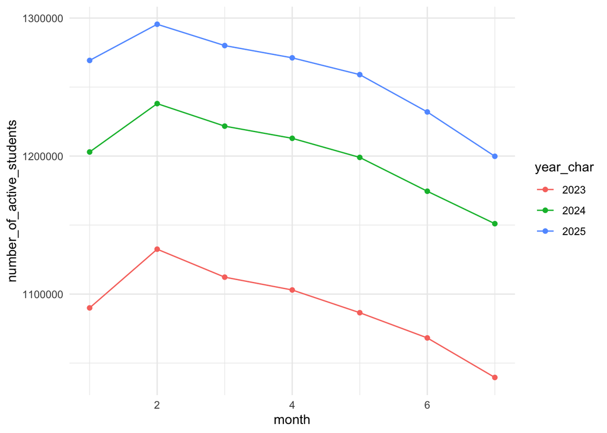

##### By country of origin

Taking the same analysis to the top 6 countries of origin, we can see a mixed pattern. The growth rate has slowed for India and Canada, but increased for Brazil and Nepal. China, as previously noted, has seen decreasing enrollment.

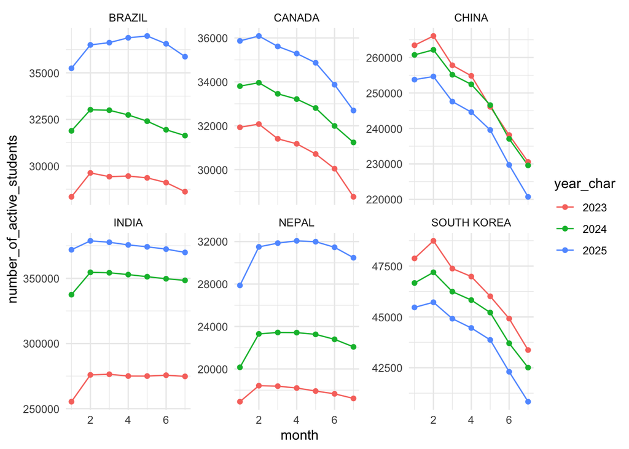

##### By state

Florida and Texas have seen consistent gains from 2023 to 2025, while California, Pennsylvania and Massachusetts stopped growing after 2024.

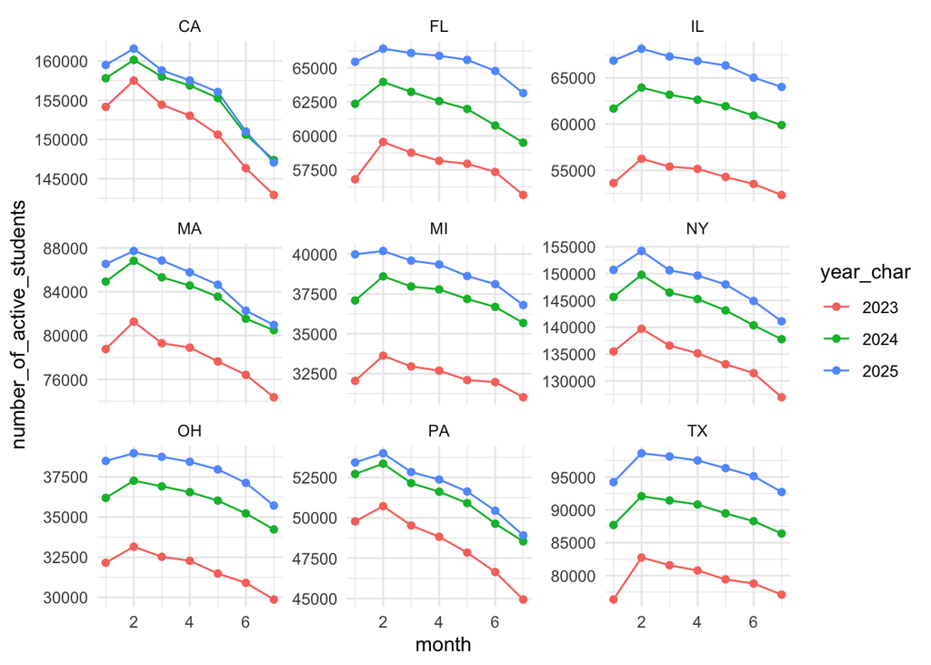